# Data Science project 2021

**Recidivism prediction** based on ProPublicas COMPAS data

**By:**

- Thu Ngan Le - 77211885855
- Philipp Heitmann - 77211890824
- Lilit Harutyunyan - 77211906776
- Johana Estrada - 77211902950
- Jonas Pieper - 77211887976

## Content:

- Intro: ProPublica's COMPAS analysis
- Data preparation
- Feature selection
- Models for Classification (general recidivism) and regression (COMPAS scores for recidivism)
  - Model iteration
  - Scoring and comparison of trained models (cross-validated and test scores)
  - Explanation of best model using `SHAP`
- Fairness discussion

# Intro: ProPublica's COMPAS analysis

- ProPublica obtained records for nearly 12,000 defendants in Broward County, Fla., who were assigned a COMPAS score in 2013-2014.
- ProPublica then determined which defendants were charged with new crimes in the subsequent two years, and made this data set publicly available.

## Correct ProPublica Two-Year Dataset

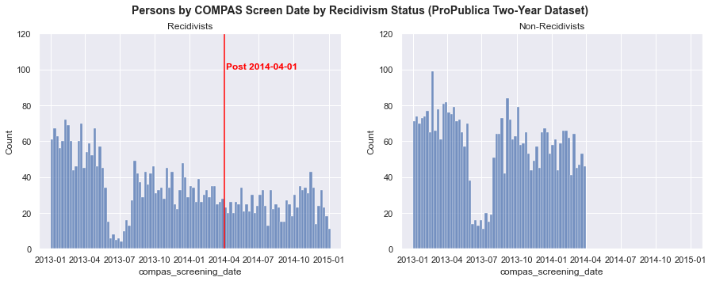

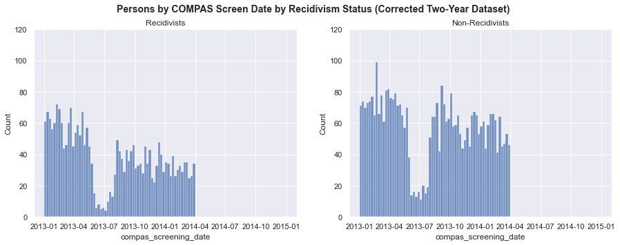

```
No. of rows in ProPublica's original dataset: 7214
No. of rows in corrected dataset: 6216
```

# Data preprocessing & Feature Engineering

## Feature Engineering: `c_charge_degree_detailed`

We ranked the degree of crime in 5 categories according to Florida law:

- M1: Misdemeanours type 1 (simple Battery, Shoplifting, Prostitution, ...)
- M2: Misdemeanours type 2 (simple assault, driving with a suspended license, ...)
- F3: Third degree Felony (illegal drug possession, burglary, drive under influence, ...)
- F2: Second degree Felony (aggravated battery with a weapon, sexual battery, ...)
- F1: First degree Felony (robbery with a weapon, human trafficking, ...)

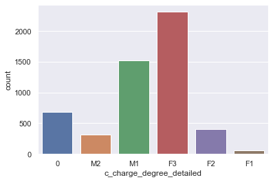

## Final dataframe for modeling

|  | age | age_cat | sex | juv_fel_count | juv_misd_count | juv_other_count | priors_count | c_charge_degree | c_charge_degree_detailed | two_year_recid |
| --- | --- | --- | --- | --- | --- | --- | --- | --- | --- | --- |
| 0 | 69 | Greater than 45 | Male | 0 | 0 | 0 | 0 | F | F3 | 0 |
| 1 | 34 | 25 - 45 | Male | 0 | 0 | 0 | 0 | F | F3 | 1 |
| 2 | 24 | Less than 25 | Male | 0 | 0 | 1 | 4 | F | F3 | 1 |
| 3 | 44 | 25 - 45 | Male | 0 | 0 | 0 | 0 | M | M1 | 0 |
| 4 | 41 | 25 - 45 | Male | 0 | 0 | 0 | 14 | F | F3 | 1 |

## Create preprocessing pipeline

- `preproc_numerical` → numerical features
- `preproc_ordinal` → ordinal features
- `preproc_nominal` → categorical features

```
ColumnTransformer(transformers=[('pipeline-1',
                                 Pipeline(steps=[('simpleimputer',
                                                  SimpleImputer())]),
                                 ['age', 'juv_fel_count', 'juv_misd_count',
                                  'juv_other_count', 'priors_count']),
                                ('pipeline-2',
                                 Pipeline(steps=[('ordinalencoder',
                                                  OrdinalEncoder(categories=[['Less '
                                                                              'than '
                                                                              '25',
                                                                              '25 '
                                                                              '- '
                                                                              '45',
                                                                              'Greater '
                                                                              'than '
                                                                              '45'],
                                                                             ['M',
                                                                              'F'],
                                                                             ['0',
                                                                              'M2',
                                                                              'M1',
                                                                              'F3',
                                                                              'F2',
                                                                              'F1']],
                                                                 dtype=<cl...>,
                                                                 handle_unknown='use_encoded_value',
                                                                 unknown_value=-1)),
                                                 ('knnimputer',
                                                  KNNImputer(missing_values=-1,
                                                             n_neighbors=25))]),
                                 ['age_cat', 'c_charge_degree',
                                  'c_charge_degree_detailed']),
                                ('pipeline-3',
                                 Pipeline(steps=[('simpleimputer',
                                                  SimpleImputer(strategy='most_frequent')),
                                                 ('onehotencoder',
                                                  OneHotEncoder(drop='if_binary',
                                                                handle_unknown='ignore'))]),
                                 ['sex'])])
```

A short Test:

|  | age | juv_fel_count | juv_misd_count | juv_other_count | priors_count | age_cat | c_charge_degree | c_charge_degree_detailed | sex_Male |
| --- | --- | --- | --- | --- | --- | --- | --- | --- | --- |
| 0 | 35.0 | 0.0 | 0.0 | 0.0 | 12.0 | 1.0 | 1.0 | 3.0 | 0.0 |
| 1 | 30.0 | 0.0 | 0.0 | 0.0 | 1.0 | 1.0 | 0.0 | 2.0 | 1.0 |
| 2 | 34.0 | 0.0 | 0.0 | 0.0 | 5.0 | 1.0 | 1.0 | 3.0 | 1.0 |

# Feature selection

- Feature correlation
- Feature permutation (MDA)
- Impurity reduction (MDI)
- Forward- and backward-feature selection (SequentialFeatureSelector)

## Feature correlation

- High correlation → redundant information
- Pearson's correlation heatmap:

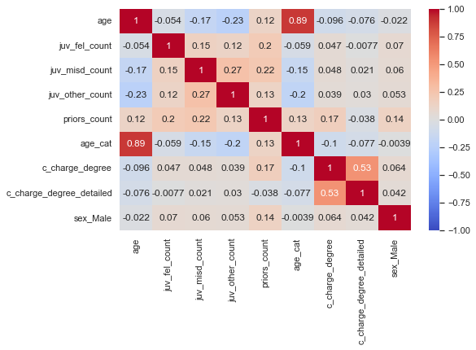

## Feature permutation (MDA)

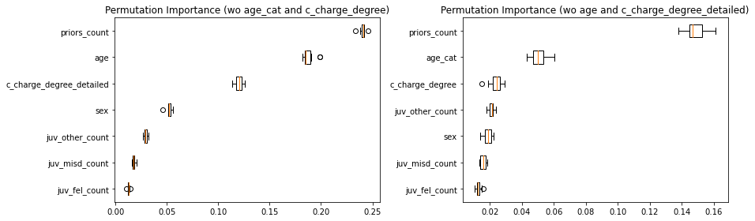

- Subset with `age` and `c_charge_degree_detailed` → more important features
- Removing `age_cat` and `c_charge_degree` → increase of overall feature importance

### Comparison subset with and without `race` as a feature

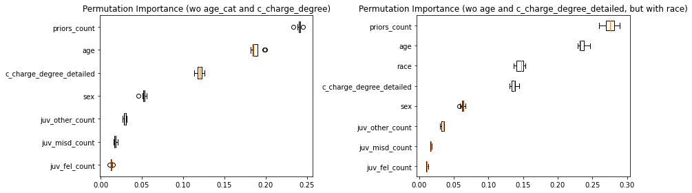

- including race as a feature → further increase of overall importance of the different features
- train another pair of models on race subset